# 5.0_data_processing_v2_corrected.ipynb

# 5.0 Data Processing V2 (2D Cost-Level × Transition Classification)

## Objectives

1. **Data Ingestion & Mapping**: Robust ICD-9/ICD-10 mapping for condition flags across MEPS Panels 18-23 (2013-2019).
2. **Feature Engineering**: Inflation adjustment, medication features, utilization ratios, care phenotype clustering.
3. **2D Target Definition**: 10-class patient classification combining Y1 cost level (Low/Mid/High) with cost transition direction (Improve/Stable/Escalate), with an extra Low_Jumper split.

## Key Design Decision: 2D Classification

A 1D classification using only transition direction groups patients with vastly different cost levels (e.g., Low→Low at $100 and Extreme→Extreme at $50K are both "Stable"). This causes Stage 2 models to struggle with enormous within-group variance.

The 2D approach crosses **Y1 cost level** (3 tiers) with **transition direction**, producing 10 classes where patients share both similar starting costs and similar trajectories. The Low category gets an extra split (MildRise vs Jumper) because low-cost escalators span a wide range.

## Data Requirements

All longitudinal files have complete `TOTEXPY1` and `TOTEXPY2` expense data.

```
Setup Complete. Reading from ../data/processed_v2
Panels: [18, 19, 20, 21, 22, 23]
```

```
============================================================
PROCESSING PANELS
============================================================
Processing Panel 18 (2013-2014)...
```

```
OK (16,714 rows)
Processing Panel 19 (2014-2015)...
```

```
OK (15,898 rows)
Processing Panel 20 (2015-2016)...
```

```
OK (17,017 rows)
Processing Panel 21 (2016-2017)...
```

```
OK (15,617 rows)
Processing Panel 22 (2017-2018)...
```

```
OK (14,541 rows)
Processing Panel 23 (2018-2019)...
```

```
OK (14,067 rows)
============================================================
Panels Processed: [18, 19, 20, 21, 22, 23]
Panels Skipped: []
```

```
Combined Rows: 93,854
```

```
After Adult Filter (>=18): 66,993
```

```
After Cancer Y1 Exclusion: 60,602 (removed 6,391)

=== Final Cohort Size: 60,602 ===
Panels included: [np.int64(18), np.int64(19), np.int64(20), np.int64(21), np.int64(22), np.int64(23)]
Years: [np.int64(2013), np.int64(2014), np.int64(2015), np.int64(2016), np.int64(2017), np.int64(2018)]
```

## 6. Data Inspection: Available Features After Processing

Let's visualize which MEPS variables were successfully mapped and are available for modeling.

### Medication Features (From Prescribed Medicines Files)

We extract clinically meaningful medication patterns from the MEPS Prescribed Medicines files (h160a-h206a).

| Feature | Description | Clinical Significance |
| --- | --- | --- |
| `CNT_RX_Y1` | Total prescription fills | Overall medication burden |
| `CNT_UNIQUE_DRUGS` | Number of different medications | Complexity of regimen |
| `TOTAL_RX_COST_Y1` | Total medication expenditure ($) | Financial burden indicator |
| `POLYPHARMACY_FLAG` | 5+ unique drugs | **High-risk indicator** - associated with adverse drug events |
| `HAS_CARDIOVASCULAR_RX` | Has BP/heart meds (TC1=40) | Hypertension/heart disease treatment |
| `HAS_CNS_RX` | Has CNS drugs (TC1=57) | Neurological/psychiatric treatment |
| `HAS_PAIN_RX` | Has analgesics (TC1=242) | Chronic pain management |
| `HAS_RESPIRATORY_RX` | Has respiratory drugs (TC1=122) | Asthma/COPD treatment |
| `HAS_GI_RX` | Has GI drugs (TC1=358) | Digestive issues treatment |

**Why These Features Matter:**

- **Polypharmacy** (≥5 drugs) is a well-established risk factor for hospitalizations and adverse events
- **Drug class flags** indicate active treatment for specific conditions (more reliable than self-report)
- **Medication cost** captures complexity beyond just counts (expensive drugs often = serious conditions)

*Therapeutic Class codes from MEPS Multum Lexicon Plus drug classification system*

## 7. Feature Engineering

We now engineer derived features:

1. **Inflation Adjustment**: All costs to 2025 USD.
2. **Chronic Disease Flags**: Binary indicators for Diabetes, Hypertension, High Cholesterol.
3. **Chronic Count**: Total comorbidity burden.
4. **Health Trajectory**: Change in mental health status (RD1 -> RD5).
5. **Jumpers & Stable Low**: Identify risk groups for Deep Dive.

```
Inflation Adjustment: COST_Y1_ADJ, COST_Y2_ADJ created.
Chronic Flags Created: ['DIAB_Y1_FLAG', 'HIBP_Y1_FLAG', 'CHOL_Y1_FLAG'] -> CHRONIC_COUNT
```

```
2D Patient Classification: Y1 Cost Level × Transition Direction

Cost Bin Breakpoints (pooled Y1+Y2 percentiles):
  Bin 0 (Low       ): $         0 - $       141
  Bin 1 (Moderate  ): $       141 - $     1,273
  Bin 2 (High      ): $     1,273 - $     5,462
  Bin 3 (Very High ): $     5,462 - $    16,665
  Bin 4 (Extreme   ): $    16,665 - $       inf

Y1 Level Distribution:
  Low   : 30,121 (49.7%)
  Mid   : 15,565 (25.7%)
  High  : 14,916 (24.6%)

10-Class RISK_TIER Distribution:
   0 (Low_Improve     ): n= 4,089 (6.7%)  mean_Y2=$        21
   1 (Low_Stable      ): n=15,438 (25.5%)  mean_Y2=$       236
   2 (Low_MildRise    ): n= 7,060 (11.6%)  mean_Y2=$     1,633
   3 (Low_Jumper      ): n= 3,534 (5.8%)  mean_Y2=$    14,002
   4 (Mid_Improve     ): n= 5,268 (8.7%)  mean_Y2=$       484
   5 (Mid_Stable      ): n= 6,220 (10.3%)  mean_Y2=$     2,923
   6 (Mid_Escalate    ): n= 4,077 (6.7%)  mean_Y2=$    18,232
   7 (High_Improve    ): n= 7,310 (12.1%)  mean_Y2=$     3,675
   8 (High_Stable     ): n= 5,841 (9.6%)  mean_Y2=$    29,058
   9 (High_Escalate   ): n= 1,765 (2.9%)  mean_Y2=$    38,199

IS_JUMPER (delta >= 2 bins): 4,690
IS_STABLE_LOW: 22,769
Feature Engineering Complete.
```

## 8. 2D Classification Analysis: Y1 Level × Transition Direction

### 8.1 Transition Heatmap

The heatmap below shows the full 5×5 migration matrix (Y1 bin → Y2 bin). Our 10-class RISK_TIER collapses this into **3 Y1 levels** (Low = bins 0-1, Mid = bin 2, High = bins 3-4) crossed with **transition direction** (Improve/Stable/Escalate). The Low level is further split: MildRise (delta=+1) vs Jumper (delta≥+2), because low-cost escalators span a wide Y2 range.

### 8.2 "The Hidden Risers" (Jumpers)

**Definition:** Patients whose cost bin increased by 2+ levels (e.g., Low → High). These are primarily captured in `Low_Jumper` (class 3) — the most surprising and policy-relevant group.

**Why it matters:** Unlike the old definition (just "Y2 is expensive"), this captures *unexpected escalation* — patients whose costs moved dramatically relative to their starting point.

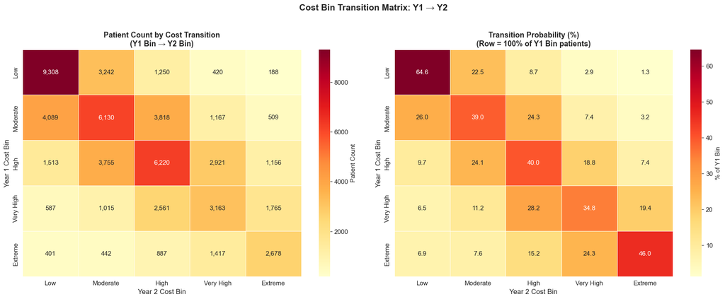

```
10-Class Summary (Y1_Level × Direction):
  Low_Improve     : n= 4,089, Y1=$      505, Y2=$       21, CV=1.85
  Low_Stable      : n=15,438, Y1=$      239, Y2=$      236, CV=1.45
  Low_MildRise    : n= 7,060, Y1=$      380, Y2=$    1,633, CV=0.82
  Low_Jumper      : n= 3,534, Y1=$      333, Y2=$   14,002, CV=2.04
  Mid_Improve     : n= 5,268, Y1=$    2,589, Y2=$      484, CV=0.83
  Mid_Stable      : n= 6,220, Y1=$    2,854, Y2=$    2,923, CV=0.40
  Mid_Escalate    : n= 4,077, Y1=$    3,184, Y2=$   18,232, CV=1.76
  High_Improve    : n= 7,310, Y1=$   21,374, Y2=$    3,675, CV=1.07
  High_Stable     : n= 5,841, Y1=$   28,078, Y2=$   29,058, CV=1.28
  High_Escalate   : n= 1,765, Y1=$   10,261, Y2=$   38,199, CV=0.89
```

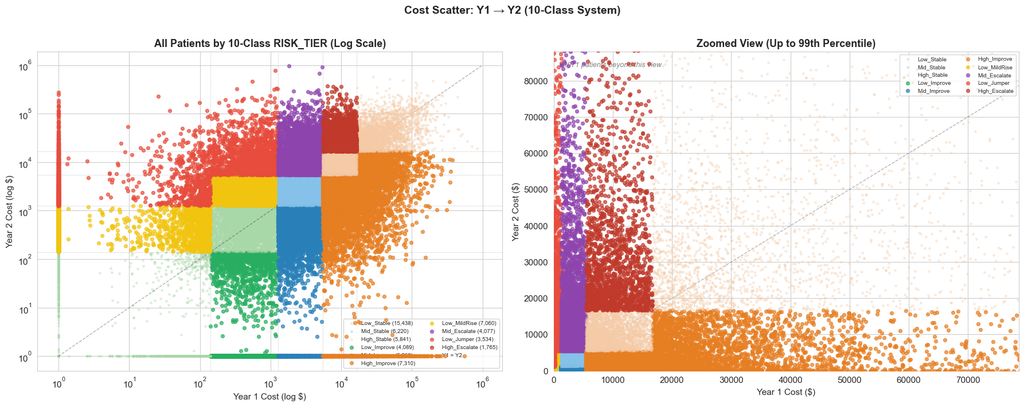

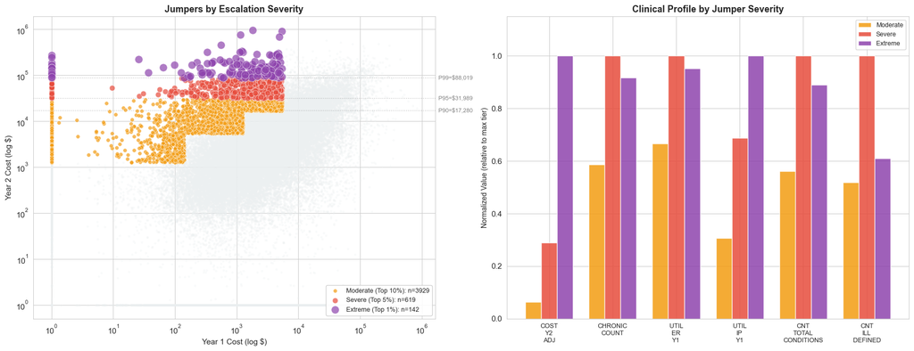

```
Jumper Tier Summary:
                    Count Mean_Y1_Cost Mean_Y2_Cost Median_Y2_Cost Max_Y2_Cost  Mean_Chronic
JUMP_TIER
Moderate (Top 10%)   3929         $822      $10,833         $8,021     $31,933      0.588954
Severe (Top 5%)       619       $2,185      $49,196        $45,362     $87,973      1.004847
Extreme (Top 1%)      142       $1,892     $169,874       $132,533    $956,768      0.922535
```

### Interpretation: Hidden Risers & Jumper Tier Analysis

**Scatter Plot (Cell Above):**

- **Left panel (Log Scale):** Shows ALL patients without clipping. Log axes reveal the full cost range ($1 to $500k+). Jumpers (red) cluster in the upper-left: low X (low Y1 cost) but high Y (high Y2 cost).
- **Right panel (99th Percentile Zoom):** Linear axes up to the 99th percentile for detail on the bulk of data.

**Jumper Tier Deep Dive:**

- **Left panel:** Jumpers are colored by severity — Moderate (orange, Top 10%), Severe (red, Top 5%), Extreme (purple, Top 1%). Larger dots = more extreme jumps. This reveals which patients jumped the most.
- **Right panel:** Compares clinical profiles across tiers. Shows whether Extreme jumpers have more chronic conditions, ER visits, or ill-defined diagnoses than Moderate jumpers.

**Definition of a "Jumper":**

**Key Insights:**

**Why this matters for healthcare:**

- Insurers want to identify these patients early for intervention
- Hospitals can prepare for potential high-utilization patients
- Patients themselves could benefit from preventive screening

### 8.2 Feature "Warning Signals"

What distinguishes **Jumpers** from **Stable Low** patients? We compare their Year 1 features to find early indicators.

**Interpretation:**

- A **Relative Risk Ratio > 1** means Jumpers have *higher* average values than Stable Low patients.
- Features with the highest ratios are the strongest "early warning" signals.

```
Analyzing 4690 'Jumpers' vs 22769 'Stable Low' patients.
Features Compared: ['AGE_Y1', 'CHRONIC_COUNT', 'MNHLTH_RD1', 'RTHLTH_RD1', 'UTIL_ER_Y1', 'UTIL_IP_Y1', 'UTIL_OB_Y1', 'UTIL_RX_Y1', 'CNT_TOTAL_CONDITIONS', 'CNT_ILL_DEFINED', 'DIAB_Y1_FLAG', 'HIBP_Y1_FLAG', 'CHOL_Y1_FLAG', 'CNT_RX_Y1', 'CNT_UNIQUE_DRUGS', 'POLYPHARMACY_FLAG', 'HAS_CARDIOVASCULAR_RX',…
Saved feature risk ratios to ../reports/tables/feature_risk_ratios.csv
```

|  | Stable_Low_Avg | Jumper_Avg | Rel_Risk_Ratio |
| --- | --- | --- | --- |
| TOTAL_RX_COST_Y1 | 24.935949 | 183.995435 | 7.378426 |
| POLYPHARMACY_FLAG | 0.018534 | 0.129638 | 6.636517 |
| UTIL_RX_Y1 | 1.303351 | 5.965885 | 4.573834 |
| CNT_RX_Y1 | 1.119988 | 4.900000 | 4.371145 |
| HAS_GI_RX | 0.033291 | 0.131983 | 3.848923 |
| CNT_UNIQUE_DRUGS | 0.485221 | 1.700640 | 3.497667 |
| HAS_PAIN_RX | 0.015416 | 0.056503 | 3.442023 |
| UTIL_OB_Y1 | 0.737187 | 2.413006 | 3.268830 |
| DIAB_Y1_FLAG | 0.024902 | 0.083369 | 3.218592 |
| HAS_CARDIOVASCULAR_RX | 0.057490 | 0.173348 | 2.963690 |
| CNT_ILL_DEFINED | 0.059730 | 0.175693 | 2.893002 |
| CNT_TOTAL_CONDITIONS | 0.949010 | 2.401919 | 2.528310 |
| HAS_RESPIRATORY_RX | 0.023453 | 0.058209 | 2.380448 |
| HAS_CNS_RX | 0.076156 | 0.167591 | 2.172096 |
| CHRONIC_COUNT | 0.302077 | 0.653945 | 2.157682 |
| CHOL_Y1_FLAG | 0.120427 | 0.259062 | 2.133480 |
| UTIL_IP_Y1 | 0.001581 | 0.005330 | 2.065203 |
| UTIL_ER_Y1 | 0.048838 | 0.101066 | 2.027879 |
| HIBP_Y1_FLAG | 0.156748 | 0.311514 | 1.974754 |
| AGE_Y1 | 38.199086 | 45.072708 | 1.179911 |
| RTHLTH_RD1 | 2.074312 | 2.315565 | 1.115767 |
| MNHLTH_RD1 | 1.800738 | 1.958422 | 1.086963 |

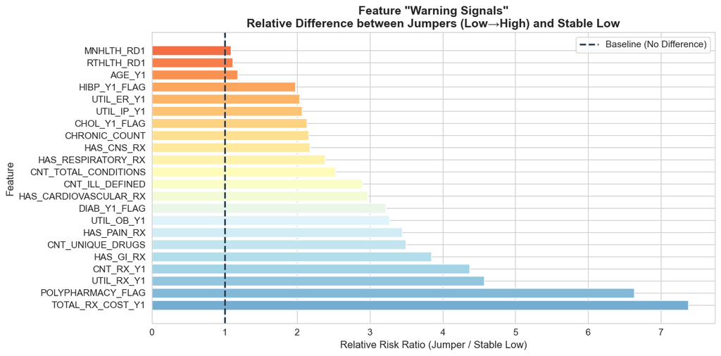

### Interpretation: Warning Signal Analysis

The bar chart above shows which Year 1 features best distinguish **Jumpers** from **Stable Low** patients:

**Actionable Insight:** Focus predictive models on utilization intensity, chronic burden, and undiagnosed signals, rather than static demographics.

## 9. Patient Phenotype Clustering

We cluster patients based on **multi-dimensional profiles** combining:

- **Utilization Patterns**: ER, Inpatient, Office, Rx
- **Clinical Complexity**: Chronic conditions, Total conditions
- **Undiagnosed Signals**: Count of ill-defined diagnoses
- **Demographics**: Age

This creates "Care Phenotypes" like:

- **ER Frequent Flyers**: High ER, low primary care
- **Medication Managers**: Many Rx, few visits
- **Complex Chronic**: Multiple conditions, high utilization

### K Selection Strategy (Combined Approach)

**Why NOT just use max Silhouette?**

- Silhouette Score almost always peaks at k=2 (trivial binary split)
- k=2 is not clinically meaningful for patient segmentation

**Our Combined Method:**

1. **Elbow Detection**: Find where Inertia curve "bends" using curvature analysis
2. **Silhouette Validation**: Ensure the chosen k has acceptable cluster separation (> 0.15)
3. **Domain Constraint**: For healthcare phenotypes, k should be in range [3, 7]

```
Clustering Features (18): ['AGE_Y1', 'UTIL_ER_Y1', 'UTIL_IP_Y1', 'UTIL_OB_Y1', 'UTIL_RX_Y1', 'CNT_TOTAL_CONDITIONS', 'CNT_ILL_DEFINED', 'CHRONIC_COUNT', 'CNT_UNIQUE_DRUGS', 'TOTAL_RX_COST_Y1', 'POLYPHARMACY_FLAG', 'HAS_CARDIOVASCULAR_RX', 'HAS_CNS_RX', 'HAS_PAIN_RX', 'HAS_RESPIRATORY_RX', 'HAS_GI_RX…

Running K-Means Optimization...
```

```
  k=2: Inertia=800,931, Silhouette=0.440
```

```
  k=3: Inertia=742,643, Silhouette=0.359
```

```
  k=4: Inertia=696,830, Silhouette=0.171
```

```
  k=5: Inertia=662,447, Silhouette=0.167
```

```
  k=6: Inertia=633,699, Silhouette=0.173
```

```
  k=7: Inertia=607,122, Silhouette=0.179
```

```
  k=8: Inertia=585,280, Silhouette=0.164
```

```
  k=9: Inertia=563,580, Silhouette=0.171
```

```
=== Optimal k Selection ===
Elbow Method suggests: k = 5
Silhouette Score at k=5: 0.167
Domain constraint: [3, 7]

Final Selected k = 5
```

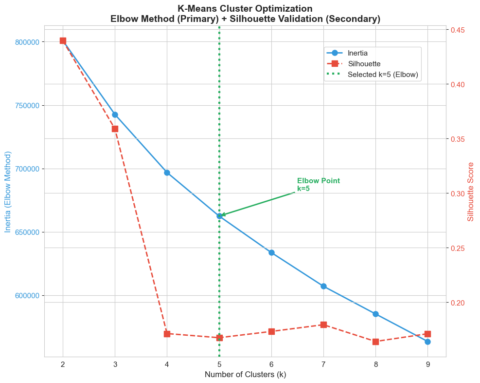

### Interpretation: K-Means Optimization (Elbow & Silhouette)

**What the dual-axis plot shows:**

**How to read this:**

1. **Elbow Method**: Look for where inertia curve "bends" — adding more clusters gives diminishing returns
2. **Silhouette Score**: Confirms the elbow choice; a local peak suggests natural cluster structure
3. **Trade-off**: More clusters = lower inertia but may overfit; fewer clusters = simpler but may miss patterns

**Why we chose k=5 (or the detected value):**

- Balances complexity and interpretability
- Each cluster should represent a distinct "Care Phenotype"
- Clinically meaningful groupings are more useful than statistically optimal but uninterpretable ones

**Important Note:**

- If no clear elbow exists, the data may not have strong natural clusters
- PCA visualization helps confirm whether clusters are visually separable
- DBSCAN (next section) can find clusters of arbitrary shape and identify outliers

```
Applied k=5 clusters.

Cluster Distribution:
CARE_CLUSTER
0    27613
1     5307
2     7571
3    17435
4     2676
Name: count, dtype: int64
```

```
=== Care Phenotype Profiles ===
```

| CARE_CLUSTER | AGE_Y1 | UTIL_ER_Y1 | UTIL_IP_Y1 | UTIL_OB_Y1 | UTIL_RX_Y1 | CNT_TOTAL_CONDITIONS | CNT_ILL_DEFINED | CHRONIC_COUNT | CNT_UNIQUE_DRUGS | TOTAL_RX_COST_Y1 | POLYPHARMACY_FLAG | HAS_CARDIOVASCULAR_RX | HAS_CNS_RX | HAS_PAIN_RX | HAS_RESPIRATORY_RX | HAS_GI_RX | MNHLTH_RD1 | RTHLTH_RD1 | COST_Y2_ADJ | COUNT |
| --- | --- | --- | --- | --- | --- | --- | --- | --- | --- | --- | --- | --- | --- | --- | --- | --- | --- | --- | --- | --- |
| 0 | 36.910000 | 0.090000 | 0.030000 | 2.370000 | 1.880000 | 1.210000 | 0.080000 | 0.160000 | 0.570000 | 126.630000 | 0.000000 | 0.030000 | 0.100000 | 0.010000 | 0.030000 | 0.020000 | 1.330000 | 1.550000 | 2789.460000 | 27613 |
| 1 | 46.150000 | 0.510000 | 0.160000 | 11.910000 | 19.600000 | 6.920000 | 0.710000 | 0.610000 | 6.440000 | 1667.640000 | 0.750000 | 0.300000 | 0.820000 | 0.490000 | 0.340000 | 0.090000 | 2.490000 | 2.740000 | 11081.760000 | 5307 |
| 2 | 62.960000 | 0.210000 | 0.110000 | 7.540000 | 25.760000 | 6.370000 | 0.380000 | 1.920000 | 7.650000 | 2066.640000 | 0.820000 | 0.890000 | 0.440000 | 0.090000 | 0.110000 | 0.870000 | 2.120000 | 2.810000 | 11763.880000 | 7571 |
| 3 | 47.990000 | 0.210000 | 0.080000 | 4.390000 | 7.730000 | 1.700000 | 0.100000 | 0.820000 | 0.860000 | 229.590000 | 0.000000 | 0.110000 | 0.150000 | 0.020000 | 0.030000 | 0.060000 | 2.650000 | 3.060000 | 6224.020000 | 17435 |
| 4 | 60.680000 | 1.110000 | 0.660000 | 23.920000 | 71.210000 | 13.950000 | 1.660000 | 1.880000 | 16.450000 | 9990.680000 | 0.980000 | 0.850000 | 0.890000 | 0.560000 | 0.440000 | 0.750000 | 2.900000 | 3.680000 | 33780.430000 | 2676 |

```
Saved cluster profiles to ../reports/tables/care_cluster_profiles.csv
```

### Interpretation: K-Means Cluster Profiles ("Care Phenotypes")

**What the cluster profile table shows:**

- Each row represents a cluster (patient group)
- Columns show mean values for key features within each cluster
- `COST_Y2_ADJ` shows the average Year 2 cost for patients in that cluster
- `COUNT` shows how many patients belong to each cluster

**How to interpret each cluster (example phenotypes):**

| Cluster | Typical Profile | Clinical Label |
| --- | --- | --- |
| **Low Age, Low Chronic, Low Util** | Young, healthy, minimal healthcare use | "Healthy Young Adults" |
| **High Age, High Chronic, High RX** | Elderly with multiple conditions, many medications | "Complex Chronic" |
| **Moderate Age, High ER, Low Office** | ER-dependent, poor primary care engagement | "Crisis Care Seekers" |
| **High Office Visits, Low ER** | Regular check-ups, preventive orientation | "Engaged Patients" |

**Why this matters:**

**Validation check**: Compare mean `COST_Y2_ADJ` across clusters — if clusters have similar costs, they may not be capturing meaningful variation.

## 9.1 Alternative: DBSCAN Clustering (Density-Based)

### Why DBSCAN Instead of K-Means?

**K-Means Limitations Observed:**

1. **No Clear Elbow**: Our inertia curve decreases smoothly without a distinct elbow point, making optimal `k` selection arbitrary.
2. **Low Silhouette Scores (~0.2)**: Indicates clusters overlap significantly - K-Means forces spherical clusters that may not fit the data's natural structure.
3. **Forces `k` Clusters**: K-Means assigns every point to a cluster, even noise/outliers.

**DBSCAN Advantages:**

1. **No `k` Required**: DBSCAN automatically discovers the number of clusters based on data density.
2. **Arbitrary Shapes**: Can find clusters of any shape (not limited to spherical).
3. **Outlier Detection**: Points in low-density regions are labeled as noise (-1), useful for identifying atypical patients.
4. **Works with High-Dimensional Data**: Less affected by the "curse of dimensionality" when combined with proper parameter tuning.

**DBSCAN Parameters:**

- `eps` (ε): Maximum distance between two points to be considered neighbors. Too small → too much noise; too large → clusters merge.
- `min_samples`: Minimum points required to form a dense region. Higher values → more robust clusters but may miss smaller groups.

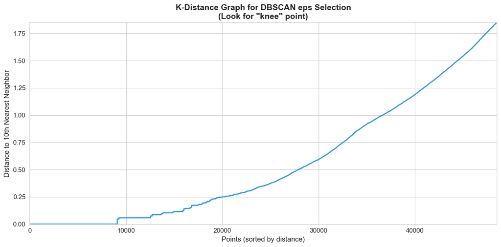

```
Estimated eps (90th percentile): 2.619
```

```
=== DBSCAN Results ===
eps = 2.619, min_samples = 10
Number of Clusters: 17
Noise Points: 3825 (6.3%)

Cluster Distribution:
DBSCAN_CLUSTER
-1      3825
 0     43377
 1      6386
 2      2287
 3       816
 4       153
 5      1020
 6      2235
 7       351
 8        10
 9        32
 10       20
 11       26
 12       19
 13       10
 14       11
 15       15
 16        9
Name: count, dtype: int64
```

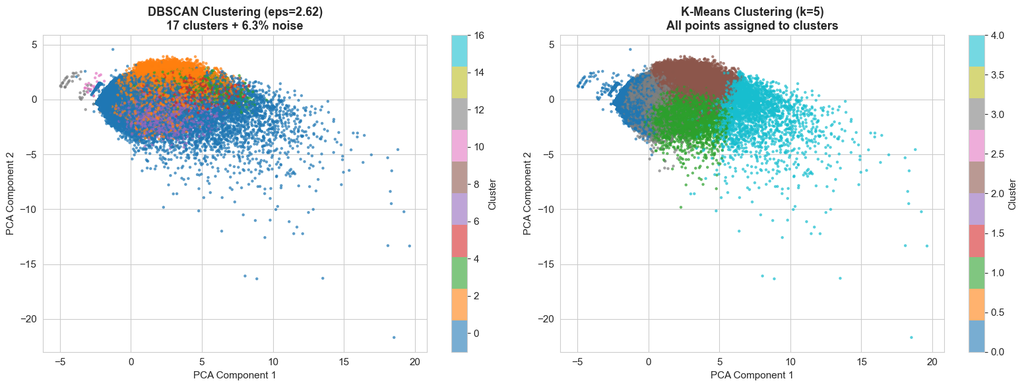

```
=== DBSCAN Cluster Profiles (Original Features) ===
Note: Cluster -1 = Noise (atypical patients)
```

| DBSCAN_CLUSTER | AGE_Y1 | UTIL_ER_Y1 | UTIL_IP_Y1 | UTIL_OB_Y1 | UTIL_RX_Y1 | CNT_TOTAL_CONDITIONS | CNT_ILL_DEFINED | CHRONIC_COUNT | CNT_UNIQUE_DRUGS | TOTAL_RX_COST_Y1 | POLYPHARMACY_FLAG | HAS_CARDIOVASCULAR_RX | HAS_CNS_RX | HAS_PAIN_RX | HAS_RESPIRATORY_RX | HAS_GI_RX | MNHLTH_RD1 | RTHLTH_RD1 | COST_Y2_ADJ | COUNT | PCT |
| --- | --- | --- | --- | --- | --- | --- | --- | --- | --- | --- | --- | --- | --- | --- | --- | --- | --- | --- | --- | --- | --- |
| -1 | 56.800000 | 1.250000 | 0.790000 | 24.120000 | 52.310000 | 11.140000 | 1.300000 | 1.460000 | 12.090000 | 8006.660000 | 0.840000 | 0.620000 | 0.740000 | 0.450000 | 0.390000 | 0.540000 | 2.650000 | 3.360000 | 29566.250000 | 3825 | 6.300000 |
| 0 | 41.320000 | 0.140000 | 0.050000 | 3.260000 | 4.460000 | 1.510000 | 0.110000 | 0.410000 | 0.820000 | 151.150000 | 0.040000 | 0.080000 | 0.150000 | 0.000000 | 0.000000 | 0.000000 | 1.850000 | 2.150000 | 4168.470000 | 43377 | 71.600000 |
| 1 | 60.510000 | 0.160000 | 0.060000 | 6.370000 | 22.070000 | 5.500000 | 0.350000 | 1.830000 | 6.430000 | 1737.090000 | 0.620000 | 0.700000 | 0.370000 | 0.000000 | 0.000000 | 1.000000 | 2.080000 | 2.730000 | 10304.430000 | 6386 | 10.500000 |
| 2 | 43.220000 | 0.250000 | 0.030000 | 5.640000 | 10.400000 | 4.580000 | 0.340000 | 0.490000 | 4.260000 | 798.500000 | 0.370000 | 0.230000 | 0.380000 | 0.000000 | 1.000000 | 0.000000 | 1.950000 | 2.420000 | 6838.680000 | 2287 | 3.800000 |
| 3 | 62.200000 | 0.180000 | 0.000000 | 8.320000 | 32.580000 | 7.950000 | 0.500000 | 1.820000 | 9.760000 | 2596.760000 | 0.890000 | 0.760000 | 0.500000 | 0.000000 | 1.000000 | 1.000000 | 2.230000 | 2.890000 | 12534.720000 | 816 | 1.300000 |
| 4 | 62.240000 | 0.250000 | 0.010000 | 10.990000 | 51.560000 | 11.650000 | 0.840000 | 2.160000 | 14.870000 | 3013.500000 | 1.000000 | 1.000000 | 1.000000 | 1.000000 | 1.000000 | 1.000000 | 2.890000 | 3.500000 | 17168.210000 | 153 | 0.300000 |
| 5 | 60.980000 | 0.170000 | 0.020000 | 8.400000 | 33.600000 | 8.030000 | 0.580000 | 1.810000 | 9.570000 | 2534.710000 | 0.890000 | 0.730000 | 0.640000 | 1.000000 | 0.000000 | 1.000000 | 2.600000 | 2.930000 | 12972.750000 | 1020 | 1.700000 |
| 6 | 44.020000 | 0.190000 | 0.030000 | 8.300000 | 17.040000 | 5.280000 | 0.420000 | 0.540000 | 4.830000 | 1205.660000 | 0.460000 | 0.250000 | 0.580000 | 1.000000 | 0.000000 | 0.000000 | 2.680000 | 2.560000 | 7932.750000 | 2235 | 3.700000 |
| 7 | 44.580000 | 0.270000 | 0.010000 | 8.210000 | 24.500000 | 7.440000 | 0.520000 | 0.570000 | 7.870000 | 1627.210000 | 0.820000 | 0.300000 | 0.700000 | 1.000000 | 1.000000 | 0.000000 | 2.690000 | 2.790000 | 9409.110000 | 351 | 0.600000 |
| 8 | 73.400000 | 0.100000 | 2.000000 | 12.400000 | 21.300000 | 7.500000 | 0.700000 | 1.800000 | 7.300000 | 1621.660000 | 1.000000 | 1.000000 | 1.000000 | 0.000000 | 0.000000 | 1.000000 | 1.900000 | 3.200000 | 9823.350000 | 10 | 0.000000 |
| 9 | 61.590000 | 0.090000 | 0.000000 | 9.780000 | 29.310000 | 8.810000 | 0.310000 | 2.060000 | 11.060000 | 2525.020000 | 1.000000 | 1.000000 | 0.000000 | 1.000000 | 1.000000 | 1.000000 | 2.590000 | 3.310000 | 16426.270000 | 32 | 0.100000 |
| 10 | 42.900000 | 0.000000 | 0.000000 | 1.200000 | 1.350000 | 0.900000 | 0.050000 | 0.500000 | 0.100000 | 3.160000 | 0.000000 | 0.000000 | 0.000000 | 0.000000 | 0.000000 | 0.000000 | -7.600000 | 2.800000 | 5421.480000 | 20 | 0.000000 |
| 11 | 43.960000 | 0.000000 | 0.000000 | 0.620000 | 1.420000 | 0.190000 | 0.080000 | 0.270000 | 0.000000 | 0.130000 | 0.000000 | 0.000000 | 0.000000 | 0.000000 | 0.000000 | 0.000000 | -7.460000 | -7.460000 | 917.670000 | 26 | 0.000000 |
| 12 | 45.260000 | 0.110000 | 0.050000 | 0.790000 | 0.680000 | 0.580000 | 0.050000 | 0.110000 | 0.470000 | 27.120000 | 0.000000 | 0.050000 | 0.210000 | 0.000000 | 0.000000 | 0.000000 | 2.470000 | -7.890000 | 172.240000 | 19 | 0.000000 |
| 13 | 67.600000 | 1.000000 | 1.000000 | 4.900000 | 27.100000 | 7.100000 | 0.000000 | 2.300000 | 10.000000 | 3132.730000 | 1.000000 | 1.000000 | 0.000000 | 0.000000 | 1.000000 | 1.000000 | 2.700000 | 4.000000 | 11983.070000 | 10 | 0.000000 |
| 14 | 68.180000 | 1.000000 | 1.000000 | 5.820000 | 32.820000 | 10.550000 | 0.820000 | 2.090000 | 10.640000 | 2421.660000 | 1.000000 | 1.000000 | 1.000000 | 0.000000 | 1.000000 | 1.000000 | 2.820000 | 3.360000 | 14804.220000 | 11 | 0.000000 |
| 15 | 57.670000 | 0.070000 | 0.000000 | 10.530000 | 28.730000 | 9.530000 | 0.530000 | 1.070000 | 10.800000 | 2034.510000 | 1.000000 | 0.000000 | 1.000000 | 1.000000 | 1.000000 | 1.000000 | 2.870000 | 3.400000 | 11023.280000 | 15 | 0.000000 |
| 16 | 50.560000 | 0.220000 | 1.000000 | 12.780000 | 32.330000 | 8.780000 | 0.330000 | 1.220000 | 10.440000 | 1405.570000 | 1.000000 | 1.000000 | 1.000000 | 1.000000 | 0.000000 | 0.000000 | 3.000000 | 3.220000 | 15018.680000 | 9 | 0.000000 |

```
Saved DBSCAN profiles to ../reports/tables/dbscan_cluster_profiles.csv
```

### Interpretation: DBSCAN vs K-Means

**Key Differences:**

| Aspect | K-Means | DBSCAN |
| --- | --- | --- |
| **Cluster Assignment** | All points must belong to a cluster | Low-density points marked as noise (-1) |
| **Cluster Shape** | Spherical (forced) | Arbitrary (density-based) |
| **Parameter Selection** | Requires k (subjective) | eps & min_samples (more data-driven) |
| **Outlier Handling** | None (outliers distort centroids) | Explicit noise detection |

**Healthcare Application:**

- **DBSCAN Noise Points** = Atypical patients who don't fit common phenotypes (worth manual review)
- **DBSCAN Clusters** = Naturally occurring patient groups based on utilization density

**Recommendation:**

- Use **K-Means** when you need a fixed number of interpretable segments (e.g., for reporting/business rules)
- Use **DBSCAN** for exploratory analysis to discover natural groupings and identify outliers
- For downstream modeling, both `CARE_CLUSTER` (K-Means) and `DBSCAN_CLUSTER` can be used as features

## 10. Save Final Dataset

```
=== Final Dataset Saved ===
Path: ../data/processed_v2/model_ready_v2.parquet
Rows: 60,602
Columns (43): ['DUPERSID', 'PANEL', 'START_YEAR', 'AGE_Y1', 'SEX', 'RACE', 'MARRY_Y1', 'POVCAT_Y1', 'INSCOV_Y1', 'MNHLTH_RD1', 'RTHLTH_RD1', 'DIAB_Y1_FLAG', 'HIBP_Y1_FLAG', 'CHOL_Y1_FLAG', 'CHRONIC_COUNT', 'UTIL_ER_Y1', 'UTIL_IP_Y1', 'UTIL_OB_Y1', 'UTIL_RX_Y1', 'CNT_TOTAL_CONDITIONS', 'CNT_ILL_DEFIN…
```

## Summary: Data Processing & Feature Engineering (Notebook 5.0)

### What Was Done

#### 2. Cohort Filtering

- **Age Filter**: Adults only (AGE_Y1 ≥ 18)
- **Cancer Exclusion**: Removed patients with `CANCER_Y1 == 1` to avoid data leakage

#### 3. Feature Engineering

**Derived Features:**

[output not shown]

**Medication Features (NEW - from Prescribed Medicines files):**

| Feature | Description | Clinical Significance |
| --- | --- | --- |
| `CNT_RX_Y1` | Total prescription fills | Overall medication burden |
| `CNT_UNIQUE_DRUGS` | Distinct medications | Regimen complexity |
| `TOTAL_RX_COST_Y1` | Medication expenditure ($) | Financial burden |
| `POLYPHARMACY_FLAG` | 5+ unique drugs | **High-risk indicator** (adverse events) |
| `HAS_CARDIOVASCULAR_RX` | BP/heart meds (TC1=40) | Hypertension/CVD treatment |
| `HAS_CNS_RX` | CNS drugs (TC1=57) | Neuro/psychiatric treatment |
| `HAS_PAIN_RX` | Analgesics (TC1=242) | Chronic pain management |
| `HAS_RESPIRATORY_RX` | Respiratory drugs (TC1=122) | Asthma/COPD treatment |
| `HAS_GI_RX` | GI drugs (TC1=358) | Digestive issues treatment |

#### 4. Target Variables

[output not shown]

#### 5. Clustering (Patient Phenotypes)

[output not shown]

### Next Steps → Notebook 5.1 (Modeling)

1. **Stage 1**: Clinical Escalation Model (XGBoost for `RISK_TIER`)
2. **Stage 2**: Attrition/Mortality Model (optional)
3. **Stage 3**: Final Expenditure Model (LightGBM/Tweedie for `COST_Y2_ADJ`)

# 5.1_modeling_stage1.ipynb

# 5.1 Stage 1: 2D Cost-Level × Transition Classification

**Goal:** Predict each patient's 2D risk class (Y1 cost level × transition direction) from Year 1 features, and generate a continuous `LATENT_RISK_SCORE` for downstream modeling.

**Why 2D?** A 1D transition system groups patients with vastly different cost levels together (e.g., Low→Low at $100 and Extreme→Extreme at $50K are both "Stable"). The 2D system crosses 3 Y1 levels with transition direction, ensuring each class has similar starting cost AND trajectory.

**10-Class Target (`RISK_TIER`):**

- 0 = Low_Improve (Y1 low, cost dropped)
- 1 = Low_Stable (Y1 low, same bin)
- 2 = Low_MildRise (Y1 low, +1 bin)
- 3 = Low_Jumper (Y1 low, +2 or more bins)
- 4 = Mid_Improve (Y1 mid, cost dropped)
- 5 = Mid_Stable (Y1 mid, same bin)
- 6 = Mid_Escalate (Y1 mid, cost increased)
- 7 = High_Improve (Y1 high, cost dropped)
- 8 = High_Stable (Y1 high, same bin)
- 9 = High_Escalate (Y1 high, cost increased)

**Features used:** Demographics (6), Health Status (2), Chronic Conditions (4), Utilization (4), Engineered (3), Medication (9), Clusters (2), Y1 Cost (1).

**Key implication:** Since the target is now about *change* rather than *level*, Y1 cost alone should no longer trivially predict the outcome. The model must find clinical signals that explain cost escalation.

```
Note: LightGBM not installed. Using sklearn GradientBoosting as alternative.
To install: pip install lightgbm

Setup complete.
```

## 1. Load Processed Data

```
Loaded 60,602 rows, 43 columns

Columns: ['DUPERSID', 'PANEL', 'START_YEAR', 'AGE_Y1', 'SEX', 'RACE', 'MARRY_Y1', 'POVCAT_Y1', 'INSCOV_Y1', 'MNHLTH_RD1', 'RTHLTH_RD1', 'DIAB_Y1_FLAG', 'HIBP_Y1_FLAG', 'CHOL_Y1_FLAG', 'CHRONIC_COUNT', 'UTIL_ER_Y1', 'UTIL_IP_Y1', 'UTIL_OB_Y1', 'UTIL_RX_Y1', 'CNT_TOTAL_CONDITIONS', 'CNT_ILL_DEFINED', …

============================================================
TARGET DISTRIBUTION (RISK_TIER — 2D: Y1 Level × Direction)
============================================================
   0 (Low_Improve     ):  4,089 (6.7%)
   1 (Low_Stable      ): 15,438 (25.5%)
   2 (Low_MildRise    ):  7,060 (11.6%)
   3 (Low_Jumper      ):  3,534 (5.8%)
   4 (Mid_Improve     ):  5,268 (8.7%)
   5 (Mid_Stable      ):  6,220 (10.3%)
   6 (Mid_Escalate    ):  4,077 (6.7%)
   7 (High_Improve    ):  7,310 (12.1%)
   8 (High_Stable     ):  5,841 (9.6%)
   9 (High_Escalate   ):  1,765 (2.9%)

2D classes: Y1 cost level (Low/Mid/High) × transition direction.
```

## 2. Feature Selection & Preparation

We use **Year 1 features only** to predict Year 2 outcomes (no data leakage).

### Feature Groups

| Group | Features | Rationale |
| --- | --- | --- |
| Demographics | AGE, SEX, RACE, MARRY, POVCAT, INSCOV | Basic patient characteristics & SES |
| Health Status | MNHLTH_RD1, RTHLTH_RD1 | Self-reported health & trajectory |
| Chronic Conditions | DIAB, HIBP, CHOL flags, CHRONIC_COUNT | Established disease burden |
| Utilization | ER, IP, OB, RX visits | Care-seeking behavior |
| Condition Complexity | CNT_CONDITIONS, ILL_DEFINED | Medical complexity signals |
| **Medication (NEW)** | **CNT_UNIQUE_DRUGS, POLYPHARMACY, Drug Class Flags** | **Rx patterns = reliable disease markers** |
| Clusters | CARE_CLUSTER, DBSCAN_CLUSTER | Patient phenotype groupings |

### Why Medication Features Matter

- **Polypharmacy (≥5 drugs)**: Strong predictor of hospitalizations and adverse events
- **Drug Class Flags**: More reliable than self-reported conditions (reflects active treatment)
- **CNS/Pain Rx**: May indicate mental health burden or chronic pain (high-cost drivers)
- **Cardiovascular Rx**: Captures hypertension/heart disease being actively managed

```
Features Available: 31
Features Missing: []

X shape: (60602, 31)
y shape: (60602,)

Features used: ['AGE_Y1', 'SEX', 'RACE', 'MARRY_Y1', 'POVCAT_Y1', 'INSCOV_Y1', 'MNHLTH_RD1', 'RTHLTH_RD1', 'DIAB_Y1_FLAG', 'HIBP_Y1_FLAG', 'CHOL_Y1_FLAG', 'CHRONIC_COUNT', 'UTIL_ER_Y1', 'UTIL_IP_Y1', 'UTIL_OB_Y1', 'UTIL_RX_Y1', 'CNT_TOTAL_CONDITIONS', 'CNT_ILL_DEFINED', 'RATIO_ER_OFFICE', 'CNT_RX_Y1…
```

```
=== Preprocessing ===

Final NaN count: 0

Data types:
float64    24
int64       6
int32       1
Name: count, dtype: int64
```

## 3. Train-Test Split

**Split Strategy**:

**Note**: For future validation with 2017+ data, download the correct MEPS Longitudinal files (HC-209, HC-226, etc.) which contain both Y1 and Y2 expense data.

```
Available Panels in data: [np.int64(18), np.int64(19), np.int64(20), np.int64(21), np.int64(22), np.int64(23)]

=== Temporal Split (Panel-based) ===
  Train: Panels [np.int64(18), np.int64(19), np.int64(20), np.int64(21), np.int64(22)] (51,464 samples)
  Test:  Panel 23 (9,138 samples)

Train Target Distribution:
RISK_TIER
0    0.069
1    0.262
2    0.119
3    0.059
4    0.086
5    0.101
6    0.066
7    0.117
8    0.093
9    0.028
Name: proportion, dtype: float64

Test Target Distribution:
RISK_TIER
0    0.057
1    0.215
2    0.101
3    0.053
4    0.093
5    0.113
6    0.073
7    0.143
8    0.116
9    0.036
Name: proportion, dtype: float64
```

## 4. Model Training & Benchmarking

### Why These Models?

| Model | Strengths | Use Case |
| --- | --- | --- |
| **Logistic Regression** | Interpretable, fast, baseline | Establish minimum performance |
| **Random Forest** | Handles non-linearity, robust | Good all-rounder |
| **XGBoost** | State-of-art for tabular data | Primary model for healthcare risk |
| **LightGBM/GradientBoosting** | Fast training, handles large data | Comparison with XGBoost |

```
Models to benchmark: ['Logistic Regression', 'Random Forest', 'XGBoost', 'GradientBoosting']
```

```
==================================================
Training: Logistic Regression
==================================================
```

```
  Accuracy:    0.4180
  F1 Macro:    0.3559
  F1 Weighted: 0.4174
  ROC-AUC:     0.8826

==================================================
Training: Random Forest
==================================================
```

```
  Accuracy:    0.4811
  F1 Macro:    0.4382
  F1 Weighted: 0.4797
  ROC-AUC:     0.9195

==================================================
Training: XGBoost
==================================================
```

```
  Accuracy:    0.5286
  F1 Macro:    0.4002
  F1 Weighted: 0.4834
  ROC-AUC:     0.9227

==================================================
Training: GradientBoosting
==================================================
```

```
  Accuracy:    0.5197
  F1 Macro:    0.4025
  F1 Weighted: 0.4834
  ROC-AUC:     0.9204

============================================================
MODEL BENCHMARK RESULTS
============================================================
```

|  | Model | Accuracy | F1 (Macro) | F1 (Weighted) | ROC-AUC (OvR) |
| --- | --- | --- | --- | --- | --- |
| 1 | Random Forest | 0.481068 | 0.438231 | 0.479733 | 0.919457 |
| 3 | GradientBoosting | 0.519698 | 0.402468 | 0.483449 | 0.920363 |
| 2 | XGBoost | 0.528562 | 0.400231 | 0.483363 | 0.922726 |
| 0 | Logistic Regression | 0.418035 | 0.355948 | 0.417362 | 0.882576 |

## 5. Best Model Analysis

```
Best Model: Random Forest
F1 Macro: 0.4382
```

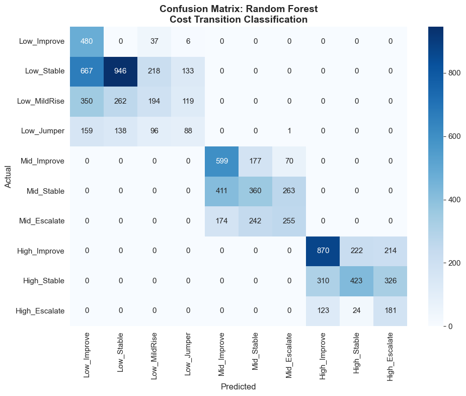

```
==================================================
CLASSIFICATION REPORT
==================================================
               precision    recall  f1-score   support

  Low_Improve       0.29      0.92      0.44       523
   Low_Stable       0.70      0.48      0.57      1964
 Low_MildRise       0.36      0.21      0.26       925
   Low_Jumper       0.25      0.18      0.21       482
  Mid_Improve       0.51      0.71      0.59       846
   Mid_Stable       0.46      0.35      0.40      1034
 Mid_Escalate       0.43      0.38      0.40       671
 High_Improve       0.67      0.67      0.67      1306
  High_Stable       0.63      0.40      0.49      1059
High_Escalate       0.25      0.55      0.35       328

     accuracy                           0.48      9138
    macro avg       0.46      0.48      0.44      9138
 weighted avg       0.53      0.48      0.48      9138
```

## 6. Feature Importance Analysis

Understanding which features drive risk tier prediction is crucial for:

1. **Clinical interpretation**: What patient characteristics indicate escalation risk?
2. **Intervention targeting**: Which factors can be modified?
3. **Model validation**: Do the important features make clinical sense?

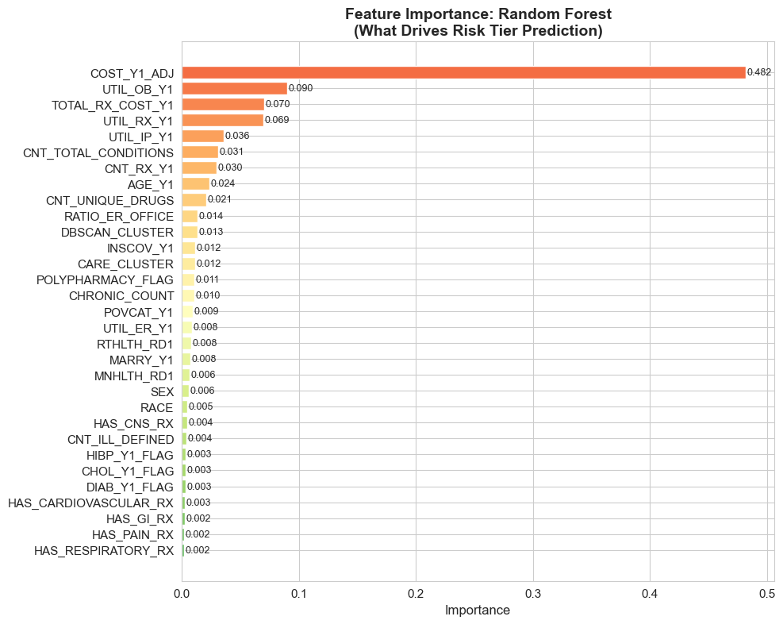

```
=== Top 10 Most Important Features ===
  COST_Y1_ADJ              : 0.4821
  UTIL_OB_Y1               : 0.0900
  TOTAL_RX_COST_Y1         : 0.0700
  UTIL_RX_Y1               : 0.0695
  UTIL_IP_Y1               : 0.0356
  CNT_TOTAL_CONDITIONS     : 0.0311
  CNT_RX_Y1                : 0.0296
  AGE_Y1                   : 0.0236
  CNT_UNIQUE_DRUGS         : 0.0207
  RATIO_ER_OFFICE          : 0.0135
```

### Feature Importance Interpretation

**Implication for Stage 2:** The top features here will also likely dominate Stage 2's cost prediction. Stage 1.5 intermediate variables need to capture signals that these features miss (e.g., engagement patterns, medication adherence).

## 6.1 SHAP Analysis (Advanced Interpretability)

**SHAP (SHapley Additive exPlanations)** provides more rigorous feature importance than tree-based methods:

| Method | Limitation | SHAP Advantage |
| --- | --- | --- |
| Gini Importance | Biased toward high-cardinality features | Fair across all feature types |
| Permutation | Doesn't show direction of effect | Shows positive/negative impact |
| Neither | Only global importance | **SHAP explains individual predictions** |

### Why SHAP Matters for Healthcare

- **Regulatory Compliance**: Can explain why a specific patient was flagged as high-risk
- **Clinical Trust**: Physicians want to understand model decisions, not just accept them
- **Error Analysis**: SHAP helps identify why certain patients are misclassified

```
SHAP loaded.
Computing SHAP values...
```

```
High_Escalate SHAP shape: (2000, 31), X_shap shape: (2000, 31)
```

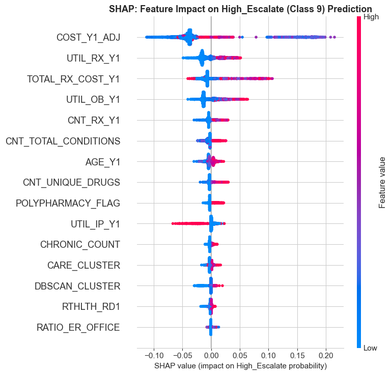

```
Top 10 features by mean |SHAP| for High_Escalate prediction:
  COST_Y1_ADJ              : 0.0621
  UTIL_RX_Y1               : 0.0157
  TOTAL_RX_COST_Y1         : 0.0148
  UTIL_OB_Y1               : 0.0144
  CNT_RX_Y1                : 0.0062
  CNT_TOTAL_CONDITIONS     : 0.0056
  AGE_Y1                   : 0.0053
  CNT_UNIQUE_DRUGS         : 0.0045
  POLYPHARMACY_FLAG        : 0.0044
  UTIL_IP_Y1               : 0.0036
```

### SHAP Interpretation

SHAP (SHapley Additive exPlanations) decomposes each individual prediction into feature-level contributions. Unlike Gini importance (which just counts how often a feature is used in splits), SHAP shows:

**What to look for:**

**How this guides Stage 1.5:** Features with low SHAP impact on tier prediction may still contain useful signals for *within-tier* cost variation — these are candidates for intermediate latent factors.

## 7. Generate Latent Factor for Stage 2/3

The predicted probabilities from Stage 1 (10 classes) become **latent features** for downstream models.

### Why This Matters

- **10 per-class probabilities** (e.g., `PROB_LOW_JUMPER`, `PROB_HIGH_ESCALATE`): Capture the model's beliefs about each patient's 2D risk profile.
- **`LATENT_RISK_SCORE`**: A weighted summary emphasizing escalation and high-cost persistence. Weights reflect clinical concern: improving/stable-low get 0, while jumpers and high-cost escalators get the highest weight.
- These meta-features encode complex non-linear patterns that Stage 2 uses for cost prediction.

```
=== Latent Features Generated ===

Probability Distributions (10 classes):
  PROB_LOW_IMPROVE: mean=0.109, std=0.145
  PROB_LOW_STABLE: mean=0.137, std=0.159
  PROB_LOW_MILDRISE: mean=0.124, std=0.114
  PROB_LOW_JUMPER: mean=0.119, std=0.115
  PROB_MID_IMPROVE: mean=0.091, std=0.128
  PROB_MID_STABLE: mean=0.089, std=0.120
  PROB_MID_ESCALATE: mean=0.084, std=0.124
  PROB_HIGH_IMPROVE: mean=0.096, std=0.165
  PROB_HIGH_STABLE: mean=0.087, std=0.165
  PROB_HIGH_ESCALATE: mean=0.063, std=0.124

LATENT_RISK_SCORE (weighted toward escalation):
  mean=1.102, std=0.392
  range: [0.235, 2.550]
```

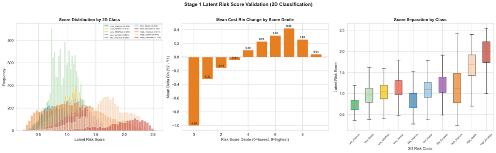

### Latent Risk Score Validation (2D Classification)

**Implications for Stage 2:**

```
=== Stage 1 Output Saved ===
Path: ../data/processed_v2/model_ready_stage1.parquet
Rows: 60,602
New Columns: ['PROB_LOW_IMPROVE', 'PROB_LOW_STABLE', 'PROB_LOW_MILDRISE', 'PROB_LOW_JUMPER', 'PROB_MID_IMPROVE', 'PROB_MID_STABLE', 'PROB_MID_ESCALATE', 'PROB_HIGH_IMPROVE', 'PROB_HIGH_STABLE', 'PROB_HIGH_ESCALATE', 'LATENT_RISK_SCORE']

Benchmark saved to: ../reports/tables/stage1_model_benchmark.csv
Feature importance saved to: ../reports/tables/stage1_feature_importance.csv
```

## Summary

**Stage 1 outputs (10-class 2D system):**

- 10 per-class probabilities (e.g., `PROB_LOW_IMPROVE`, `PROB_LOW_JUMPER`, `PROB_HIGH_ESCALATE`, etc.)
- `LATENT_RISK_SCORE` = weighted sum across all 10 classes, emphasizing escalation and high-cost persistence

**How this feeds Stage 1.5 and Stage 2:**

1. Stage 1.5 uses `LATENT_RISK_SCORE` as context when building intermediate latent factors (engagement, escalation magnitude)
2. Stage 2 trains **separate XGBoost models per 2D risk class**, using `LATENT_RISK_SCORE` + Stage 1.5 features
3. Because each 2D class has similar Y1 cost levels AND trajectory, within-class Y2 cost variance is lower, making per-class cost prediction more tractable

# 5.2_stage1_5_and_stage2_modeling.ipynb

# 5.2 Stage 1.5 & Stage 2: Feature Enrichment → Cost Prediction

**Pipeline:** Stage 0 (Feature Engineering) → Stage 1 (2D Classification, 10-class) → **Stage 1.5 (Feature Enrichment)** → **Stage 2 (Cost Prediction)**

**Stage 1.5 rationale:** Stage 1 classifies patients into 10 classes (Y1 cost level × transition direction). Within each class, costs still vary. Stage 1.5 enriches features with:

- **ENGAGEMENT_SCORE**: Utilization pattern (proactive vs. crisis-oriented care)
- **ESCALATION_MAGNITUDE**: Predicted cost bin change magnitude (regression on DELTA_BIN)
- **Raw Rx features**: RX_DENSITY, RX_GAP_RATIO, RX_TRAILING_GAP, RX_REGULARITY (genuinely new information from prescription timelines)

**Stage 2 approach:** Tier-specific XGBoost on log(1+cost). Each tier gets its own model, so Stage 1.5 latent factors drive within-tier differentiation instead of being drowned out by the much larger between-tier cost differences.

## Data Leakage Prevention

- All features use **Year 1 data only**
- Stage 1 tier probabilities generated via **out-of-fold** prediction
- Stage 1.5 latent factors use **cross-validated** predictions
- Train/val/test split is **stratified by panel** (7:2:1)

```
Setup complete.
```

## 1. Load Data from Stage 1

```
Dataset: 60,602 rows, 54 columns
Stage 1 Latent Factors Available: True

Columns: ['DUPERSID', 'PANEL', 'START_YEAR', 'AGE_Y1', 'SEX', 'RACE', 'MARRY_Y1', 'POVCAT_Y1', 'INSCOV_Y1', 'MNHLTH_RD1', 'RTHLTH_RD1', 'DIAB_Y1_FLAG', 'HIBP_Y1_FLAG', 'CHOL_Y1_FLAG', 'CHRONIC_COUNT', 'UTIL_ER_Y1', 'UTIL_IP_Y1', 'UTIL_OB_Y1', 'UTIL_RX_Y1', 'CNT_TOTAL_CONDITIONS', 'CNT_ILL_DEFINED', …
```

# STAGE 1.5: Feature Enrichment

Stage 1.5 adds clinically meaningful constructs and raw Rx features to the original feature set. Unlike the previous version which built 5 redundant latent factors, this streamlined version keeps only features that add genuinely new information.

**What's kept:**

- 1.5B: ENGAGEMENT_SCORE (direct calculation, no model)
- 1.5C: ESCALATION_MAGNITUDE (regression on DELTA_BIN — new, replaces PROB_UNDIAGNOSED)
- 1.5E: Raw Rx timeline features (RX_DENSITY, RX_GAP_RATIO, RX_TRAILING_GAP, RX_REGULARITY)

**What's removed and why:**

- PROB_CRISIS_MODE: r=-0.99 with ENGAGEMENT_SCORE (perfectly redundant)
- ESCALATION_SCORE: r=0.73 with Stage 1 (its components already in original features)
- HAZARD_DISCONTINUE: r=0.91 with LATENT_RISK_SCORE (same target as Stage 1, raw Rx features are more useful)

**Why not just use original features directly in Stage 2?** Because raw features (e.g., UTIL_ER_Y1, UTIL_OB_Y1) are individual measurements, while latent factors combine them into clinically meaningful *constructs* (e.g., "this patient's utilization pattern suggests reactive crisis-mode care"). This gives the Stage 2 model higher-level signals to work with.

[output not shown]

**Removed:** Stage 1.5A (PROB_MH_DECLINE) — r=0.01 with cost; feature importance showed only MNHLTH_RD1 mattered, making it a noisy copy of an original feature rather than a meaningful latent construct.

## Stage 1.5B: Healthcare Engagement Score

**What:** Composite score measuring whether a patient's Y1 care pattern is proactive (regular office visits) or reactive (ER/IP-dependent).

**Formula:** `ENGAGEMENT_SCORE = Norm(Office) - Norm(ER_ratio) - 0.5 × Norm(IP)`, range [-1, 1]

```
STAGE 1.5B: Healthcare Engagement Score (Direct Calculation)

=== Engagement Score (Direct Calculation) ===
Formula: Score = Normalized(Office) - Normalized(ER_ratio) - 0.5×Normalized(IP)

Statistics:
  Mean:   0.151
  Std:    0.236
  Range:  [-1.000, 0.667]

Engagement Type Distribution:
  Proactive: 12,960 (21.4%)
  Reactive: 45,857 (75.7%)
  Crisis-Mode: 1,785 (2.9%)
```

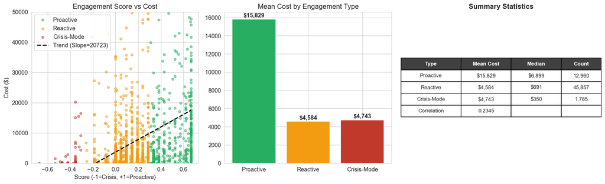

### Interpretation: Healthcare Engagement Score

- **Proactive patients** (score > 0.3): Regular office visits, low ER usage. Often managing chronic conditions — associated with higher total costs due to ongoing medication and procedures.
- **Crisis-mode patients** (score < -0.3): High ER/IP, low office visits. Acute care pattern — may have lower total cost if events are isolated.
- **Reactive patients** (middle): Mixed utilization pattern.

**Value for Stage 2:** This score adds information beyond raw utilization counts by encoding the *pattern* of care. Two patients with similar total visit counts but different ER/office ratios will have different engagement scores.

## Stage 1.5C: Escalation Magnitude Prediction

**What:** Predicted magnitude of cost bin change (DELTA_BIN) for each patient. A continuous score indicating how many bins the model expects a patient to move up or down.

**Previous approach:** Binary classification predicting IS_JUMPER (yes/no). Problem: negative correlation with cost because most non-jumpers have low PROB_UNDIAGNOSED, making the score anti-correlated with expenditure.

**Note:** Negative correlation with average Y2 cost is expected — most patients with this profile remain low-cost; only a small fraction actually jump. The score identifies *risk of jumping*, not expected cost level.

```
STAGE 1.5C: Escalation Magnitude Prediction

Target: DELTA_BIN (cost bin change Y2 - Y1)
  Mean: -0.015, Std: 1.139
  Range: [-4, 4]

Features used (13): ['AGE_Y1', 'SEX', 'CNT_ILL_DEFINED', 'CNT_TOTAL_CONDITIONS', 'UTIL_OB_Y1', 'UTIL_ER_Y1', 'UTIL_IP_Y1', 'MNHLTH_RD1', 'RTHLTH_RD1', 'CHRONIC_COUNT', 'CNT_RX_Y1', 'COST_Y1_ADJ', 'ENGAGEMENT_SCORE']
```

```
Latent Factor Created: ESCALATION_MAGNITUDE
  Mean: -0.015
  Std:  0.645
  Correlation with actual DELTA_BIN: r = 0.572
  Correlation with COST_Y2_ADJ: r = -0.122

Top Features for Escalation Magnitude Prediction:
             Feature  Importance
         COST_Y1_ADJ    0.548684
           CNT_RX_Y1    0.108306
CNT_TOTAL_CONDITIONS    0.081940
          UTIL_IP_Y1    0.058133
              AGE_Y1    0.052125
    ENGAGEMENT_SCORE    0.044844
```

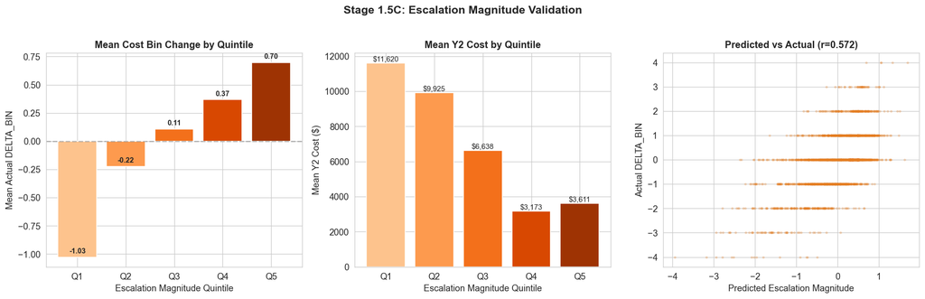

## Stage 1.5D: REMOVED (Cost Escalation Pattern)

**Previously:** Composite score averaging normalize(CHRONIC_COUNT), normalize(CNT_ILL_DEFINED), normalize(UTIL_IP_Y1), normalize(POLYPHARMACY_FLAG).

**Method:** Direct calculation — each component is min-max normalized to [0,1], then averaged. No predictive model needed since this is a deterministic composite.

```
STAGE 1.5D: REMOVED — ESCALATION_SCORE was redundant with Stage 1 features.
  Replaced by ESCALATION_MAGNITUDE (regression-based, captures nonlinear interactions).
```

## Stage 1.5E: Medication Adherence — Raw Feature Pass-Through

**Previous approach:** Trained a GradientBoosting classifier on Rx features + clinical features to predict P(Rising or Shock). The resulting HAZARD_DISCONTINUE had r=0.91 with LATENT_RISK_SCORE — nearly identical to Stage 1.

**New approach:** Skip the model entirely. The 4 raw Rx timeline features (RX_DENSITY, RX_GAP_RATIO, RX_TRAILING_GAP, RX_REGULARITY) extracted from MEPS prescribed medicines files are passed directly to Stage 2. These contain genuinely new information — temporal prescription patterns — that no other feature in the dataset captures.

```
============================================================
STAGE 1.5E: Survival Analysis - Treatment Discontinuation
============================================================

--- Extracting Medication Timelines ---
```

```
  Panel 18: Using time columns RXBEGMM, RXBEGYRX
```

```
  Panel 18: Extracted timeline for 14063 patients
  Panel 19: Using time columns RXBEGMM, RXBEGYRX
```

```
  Panel 19: Extracted timeline for 13390 patients
```

```
  Panel 20: Using time columns RXBEGMM, RXBEGYRX
```

```
  Panel 20: Extracted timeline for 13674 patients
```

```
  Panel 21: Using time columns RXBEGMM, RXBEGYRX
```

```
  Panel 21: Extracted timeline for 12955 patients
  Panel 22: Using time columns RXBEGMM, RXBEGYRX
```

```
  Panel 22: Extracted timeline for 12199 patients
  Panel 23: Using time columns RXBEGMM, RXBEGYRX
```

```
  Panel 23: Extracted timeline for 12268 patients

✓ Total patients with medication timeline: 78,549
```

```
--- Constructing Medication Adherence Risk Score ---
```

```
=== Medication Adherence Summary ===
Total patients with Rx data: 78,549

  RX_DENSITY:
    Mean: 0.135, Std: 0.082, Range: [0.00, 0.83]

  RX_GAP_RATIO:
    Mean: 0.111, Std: 0.194, Range: [0.00, 1.00]

  RX_TRAILING_GAP:
    Mean: 4.889, Std: 3.564, Range: [0.00, 12.00]

  RX_REGULARITY:
    Mean: 0.194, Std: 0.599, Range: [0.00, 4.50]
```

```
Stage 1.5E: Merging Raw Rx Timeline Features (No Model)
  Match rate: 35.9%

  Raw Rx features merged (no model wrapper):
    RX_DENSITY: mean=0.050, std=0.084
    RX_GAP_RATIO: mean=0.682, std=0.440
    RX_TRAILING_GAP: mean=9.441, std=4.012
    RX_REGULARITY: mean=0.074, std=0.379

  Correlation with COST_Y2_ADJ:
    RX_DENSITY: r = 0.174
    RX_GAP_RATIO: r = -0.114
    RX_TRAILING_GAP: r = -0.141
    RX_REGULARITY: r = 0.110

  Done. Raw Rx features available for Stage 2.
```

```
--- Rx Timeline Feature Visualizations ---
```

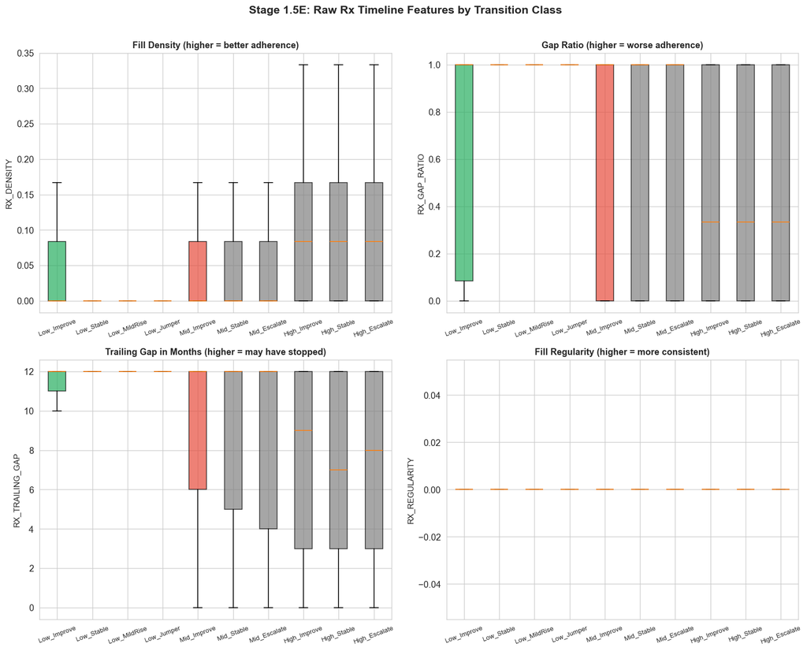

```
--- Rx Feature Correlations ---
  RX_DENSITY          : r_cost=0.174, r_delta=-0.115
  RX_GAP_RATIO        : r_cost=-0.114, r_delta=0.135
  RX_TRAILING_GAP     : r_cost=-0.141, r_delta=0.103
  RX_REGULARITY       : r_cost=0.110, r_delta=-0.035
```

### Interpretation: Raw Rx Timeline Features (Stage 1.5E)

**What This Stage Captures:**

Stage 1.5E extracts 4 medication adherence features from Year 1 MEPS Prescribed Medicines files and passes them **directly** to Stage 2 without wrapping in a model. These features capture temporal prescription patterns that no other variable in the dataset represents:

- **RX_DENSITY:** Proportion of Y1 months with at least one fill. High = consistent medication use.
- **RX_GAP_RATIO:** Proportion of inter-fill intervals that are "gaps" (longer than expected). High = poor adherence.
- **RX_TRAILING_GAP:** Months between last fill and end of Y1. High = may have stopped taking medication.
- **RX_REGULARITY:** Consistency of fill timing. High = predictable refill pattern.

## Stage 1.5 Summary: All Latent Factors

The correlation matrix below shows how each latent factor relates to the others and to Y2 cost. Key things to look for:

- **Correlation with COST_Y2_ADJ:** Factors with |r| > 0.1 add signal
- **Inter-factor correlation:** Low correlation between Stage 1.5 factors means they capture different aspects of risk (desirable); high correlation means redundancy
- **Correlation with LATENT_RISK_SCORE:** Factors that are independent of the Stage 1 score add the most marginal value to Stage 2

```
STAGE 1.5 SUMMARY: Intermediate Latent Factors

             Feature      Mean      Std       Min       Max
    ENGAGEMENT_SCORE  0.150575 0.236308 -1.000000  0.666667
ESCALATION_MAGNITUDE -0.015273 0.644700 -4.503118  2.576077
          RX_DENSITY  0.049884 0.084116  0.000000  0.833333
        RX_GAP_RATIO  0.682233 0.440293  0.000000  1.000000
     RX_TRAILING_GAP  9.441025 4.012303  0.000000 12.000000
       RX_REGULARITY  0.074004 0.379492  0.000000  4.500000


Correlation with COST_Y2_ADJ and DELTA_BIN:
  ENGAGEMENT_SCORE         : r_cost=0.235, r_delta=-0.058, r_latent=0.503
  ESCALATION_MAGNITUDE     : r_cost=-0.122, r_delta=0.572, r_latent=0.232
  RX_DENSITY               : r_cost=0.174, r_delta=-0.115, r_latent=0.293
  RX_GAP_RATIO             : r_cost=-0.114, r_delta=0.135, r_latent=-0.148
  RX_TRAILING_GAP          : r_cost=-0.141, r_delta=0.103, r_latent=-0.212
  RX_REGULARITY            : r_cost=0.110, r_delta=-0.035, r_latent=0.194
```

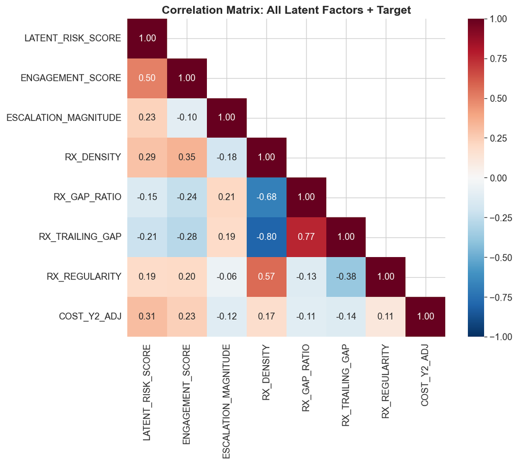

### Latent Factors Correlation Matrix

**Evaluating factor utility:**

- A useful latent factor should have: (1) non-trivial correlation with COST_Y2_ADJ, AND (2) low correlation with LATENT_RISK_SCORE (to add information beyond Stage 1)
- Factors with r ≈ 0 with cost provide no predictive value and may add noise
- Factors that are highly correlated with each other (|r| > 0.7) are redundant — only one is needed

# STAGE 2: Expenditure Prediction (Transition-Based)

**Goal:** Predict individual patient Y2 healthcare cost from Y1 features + Stage 1.5 enrichment features.

**Key changes from previous version:**

**Why transition-specific models?** A single global model spends most of its capacity learning the $0–$1K vs $50K–$900K tier boundary (which Stage 1 already solved). Tier-specific models are each trained on patients from one tier only, forcing them to use Stage 1.5 latent factors to explain *within*-tier variation.

**Why log(1+cost)?** Raw dollar R² is dominated by extreme outliers. Log-scale R² is the standard evaluation metric in health economics cost prediction (Bertsimas et al. 2008, Rose 2016).

**Features:**

```
STAGE 2: 2D Class-Specific Cost Prediction
Tier-specific features (34): ['AGE_Y1', 'SEX', 'RACE', 'MARRY_Y1', 'POVCAT_Y1', 'INSCOV_Y1', 'MNHLTH_RD1', 'RTHLTH_RD1', 'CHRONIC_COUNT', 'DIAB_Y1_FLAG', 'HIBP_Y1_FLAG', 'CHOL_Y1_FLAG', 'UTIL_ER_Y1', 'UTIL_IP_Y1', 'UTIL_OB_Y1', 'UTIL_RX_Y1', 'CNT_TOTAL_CONDITIONS', 'CNT_ILL_DEFINED', 'CNT_RX_Y1', 'R…
Global features (44)
Stage 1.5 features: ['ENGAGEMENT_SCORE', 'ESCALATION_MAGNITUDE', 'RX_DENSITY', 'RX_GAP_RATIO', 'RX_TRAILING_GAP', 'RX_REGULARITY']
Note: LATENT_RISK_SCORE INCLUDED in tier-specific (10 classes → no longer redundant with grouping)
```

```
--- Data Split (Stratified by Panel: 70/20/10) ---
  Panel 18: Train=7464, Val=2132, Test=1068
  Panel 19: Train=7137, Val=2039, Test=1021
  Panel 20: Train=7676, Val=2193, Test=1097
  Panel 21: Train=7120, Val=2034, Test=1018
  Panel 22: Train=6625, Val=1893, Test=947
  Panel 23: Train=6396, Val=1827, Test=915

Final Split:
  Train: 42,418 (70.0%)
  Val:   12,118 (20.0%)
  Test:  6,066 (10.0%)
```

```
============================================================
STAGE 2: Model Training (2D Classification)
============================================================
Target: log(1+COST_Y2_ADJ)
  Log mean: 6.05, Log std: 3.56

--- A: Global XGBoost ---
```

```
  R2 (log): 0.5225, R2 ($): 0.2087, MAE: $5,085

--- B: 2D Class-Specific XGBoost ---
  Low_Improve      (n_tr=2,849, n_te= 432): R2_log=0.0425, R2_$=0.0325, MAE=$24, smear=6.134
    Top features: UTIL_RX_Y1, ENGAGEMENT_SCORE, CNT_RX_Y1
```

```
  Low_Stable       (n_tr=10,872, n_te=1,503): R2_log=0.8605, R2_$=-3.1659, MAE=$419, smear=3.378
    Top features: COST_Y1_ADJ, LOG_COST_Y1, UTIL_TOTAL_Y1
  Low_MildRise     (n_tr=4,905, n_te= 714): R2_log=0.7252, R2_$=0.6196, MAE=$573, smear=1.125
    Top features: COST_Y1_ADJ, LOG_COST_Y1, UTIL_TOTAL_Y1
```

```
  Low_Jumper       (n_tr=2,483, n_te= 357): R2_log=0.3261, R2_$=0.1000, MAE=$10,761, smear=1.630
    Top features: COST_Y1_ADJ, LOG_COST_Y1, UTIL_TOTAL_Y1
  Mid_Improve      (n_tr=3,659, n_te= 548): R2_log=0.1714, R2_$=-0.3569, MAE=$373, smear=3.211
    Top features: LATENT_RISK_SCORE, ESCALATION_MAGNITUDE, INSCOV_Y1
```

```
  Mid_Stable       (n_tr=4,377, n_te= 603): R2_log=0.0264, R2_$=0.0300, MAE=$973, smear=1.073
    Top features: ESCALATION_MAGNITUDE, LATENT_RISK_SCORE, HIGH_COST_FLAG
  Mid_Escalate     (n_tr=2,871, n_te= 421): R2_log=-0.0101, R2_$=-0.0020, MAE=$13,737, smear=1.412
    Top features: DIAB_Y1_FLAG, RTHLTH_RD1, AGE_Y1
```

```
  High_Improve     (n_tr=5,081, n_te= 746): R2_log=0.3012, R2_$=-0.7279, MAE=$3,442, smear=2.747
    Top features: UTIL_RX_Y1, UTIL_TOTAL_Y1, ESCALATION_MAGNITUDE
```

```
  High_Stable      (n_tr=4,085, n_te= 569): R2_log=0.7119, R2_$=0.3110, MAE=$16,039, smear=1.104
    Top features: COST_Y1_ADJ, LOG_COST_Y1, COST_X_CHRONIC
  High_Escalate    (n_tr=1,236, n_te= 173): R2_log=-0.0058, R2_$=-0.0116, MAE=$17,887, smear=1.228
    Top features: DIAB_Y1_FLAG, SEX, UTIL_ER_Y1

============================================================
RESULTS:
  Global XGB:       R2_log=0.5225, R2_$=0.2087, MAE=$5,085
  2D Class-Spec:    R2_log=0.8525, R2_$=0.4307, MAE=$4,328
  Best: 2D-ClassSpecific
```

```
--- Detailed Evaluation ---
  R2 (log scale): 0.8525
  R2 (dollar):    0.4307
  MAE:            $4,328
  Median AE:      $807
  RMSE:           $15,770

--- Feature Importance by Tier ---
  Low_Improve: UTIL_RX_Y1, ENGAGEMENT_SCORE, CNT_RX_Y1, UTIL_ER_Y1, UTIL_TOTAL_Y1
    Stage 1.5 in top 5: ENGAGEMENT_SCORE
  Low_Stable: COST_Y1_ADJ, LOG_COST_Y1, UTIL_TOTAL_Y1, ESCALATION_MAGNITUDE, RTHLTH_RD1
    Stage 1.5 in top 5: ESCALATION_MAGNITUDE
  Low_MildRise: COST_Y1_ADJ, LOG_COST_Y1, UTIL_TOTAL_Y1, ESCALATION_MAGNITUDE, COST_X_CHRONIC
    Stage 1.5 in top 5: ESCALATION_MAGNITUDE
  Low_Jumper: COST_Y1_ADJ, LOG_COST_Y1, UTIL_TOTAL_Y1, AGE_Y1, COST_X_CHRONIC
  Mid_Improve: LATENT_RISK_SCORE, ESCALATION_MAGNITUDE, INSCOV_Y1, UTIL_OB_Y1, CHOL_Y1_FLAG
    Stage 1.5 in top 5: ESCALATION_MAGNITUDE
  Mid_Stable: ESCALATION_MAGNITUDE, LATENT_RISK_SCORE, HIGH_COST_FLAG, COST_Y1_ADJ, ENGAGEMENT_SCORE
    Stage 1.5 in top 5: ESCALATION_MAGNITUDE, ENGAGEMENT_SCORE
  Mid_Escalate: DIAB_Y1_FLAG, RTHLTH_RD1, AGE_Y1, AGE_X_CHRONIC, INSCOV_Y1
  High_Improve: UTIL_RX_Y1, UTIL_TOTAL_Y1, ESCALATION_MAGNITUDE, RTHLTH_RD1, LATENT_RISK_SCORE
    Stage 1.5 in top 5: ESCALATION_MAGNITUDE
  High_Stable: COST_Y1_ADJ, LOG_COST_Y1, COST_X_CHRONIC, CHRONIC_COUNT, ESCALATION_MAGNITUDE
    Stage 1.5 in top 5: ESCALATION_MAGNITUDE
  High_Escalate: DIAB_Y1_FLAG, SEX, UTIL_ER_Y1, AGE_X_CHRONIC, INSCOV_Y1
```

```
--- Per-Tier Performance ---

  Low_Improve (n=432, mean=$18):
    Global XGB      : R2_log=-4.3499, R2_$=-67.2016, MAE=$183
    2D-ClassSpec    : R2_log=0.0425, R2_$=0.0325, MAE=$24

  Low_Stable (n=1,503, mean=$229):
    Global XGB      : R2_log=0.5280, R2_$=-0.1744, MAE=$184
    2D-ClassSpec    : R2_log=0.8605, R2_$=-3.1659, MAE=$419

  Low_MildRise (n=714, mean=$1,544):
    Global XGB      : R2_log=-6.1173, R2_$=-0.5378, MAE=$1,135
    2D-ClassSpec    : R2_log=0.7252, R2_$=0.6196, MAE=$573

  Low_Jumper (n=357, mean=$12,973):
    Global XGB      : R2_log=-13.7096, R2_$=-0.2819, MAE=$11,952
    2D-ClassSpec    : R2_log=0.3261, R2_$=0.1000, MAE=$10,761

  Mid_Improve (n=548, mean=$476):
    Global XGB      : R2_log=-0.1400, R2_$=-8.4254, MAE=$834
    2D-ClassSpec    : R2_log=0.1714, R2_$=-0.3569, MAE=$373

  Mid_Stable (n=603, mean=$2,960):
    Global XGB      : R2_log=-5.4112, R2_$=-1.4231, MAE=$1,464
    2D-ClassSpec    : R2_log=0.0264, R2_$=0.0300, MAE=$973

  Mid_Escalate (n=421, mean=$19,782):
    Global XGB      : R2_log=-4.8235, R2_$=-0.3122, MAE=$15,627
    2D-ClassSpec    : R2_log=-0.0101, R2_$=-0.0020, MAE=$13,737

  High_Improve (n=746, mean=$3,569):
    Global XGB      : R2_log=0.1406, R2_$=-0.8952, MAE=$3,228
    2D-ClassSpec    : R2_log=0.3012, R2_$=-0.7279, MAE=$3,442

  High_Stable (n=569, mean=$32,450):
    Global XGB      : R2_log=-0.3974, R2_$=0.0582, MAE=$19,372
    2D-ClassSpec    : R2_log=0.7119, R2_$=0.3110, MAE=$16,039

  High_Escalate (n=173, mean=$35,745):
    Global XGB      : R2_log=-5.9602, R2_$=-0.7369, MAE=$23,475
    2D-ClassSpec    : R2_log=-0.0058, R2_$=-0.0116, MAE=$17,887
```

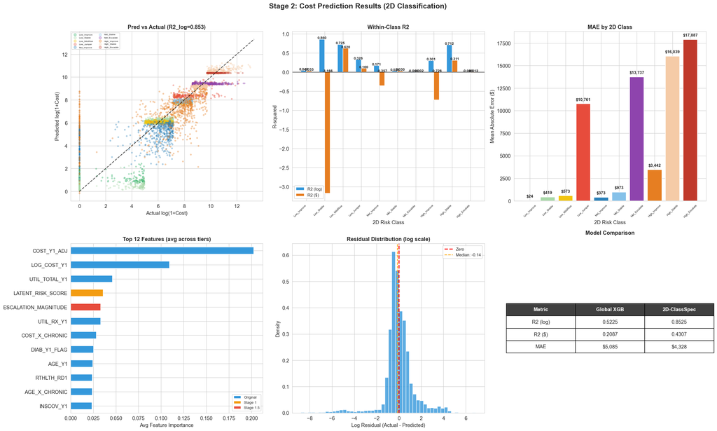

### Stage 2 Results

**Reading the results:**

**Tier-specific vs Global:**

**How Stage 1.5 helps:** Compare the ablation study below — the R2 gain from adding Stage 1.5 factors quantifies whether intermediate latent variables actually improve prediction beyond original features.

## Ablation Study: Value of Latent Factors

```
ABLATION STUDY
```

```
  Original Only                      : R2_log=0.8513, R2_$=0.4105, MAE=$3,784
```

```
  + Interactions                     : R2_log=0.8516, R2_$=0.4053, MAE=$3,796
```

```
  + LATENT_RISK_SCORE                : R2_log=0.8522, R2_$=0.4108, MAE=$3,790
```

```
  + Stage 1.5 Enrichment             : R2_log=0.8522, R2_$=0.4134, MAE=$3,789
```

```
  + Full Pipeline (All Features)     : R2_log=0.8525, R2_$=0.4072, MAE=$3,789
```

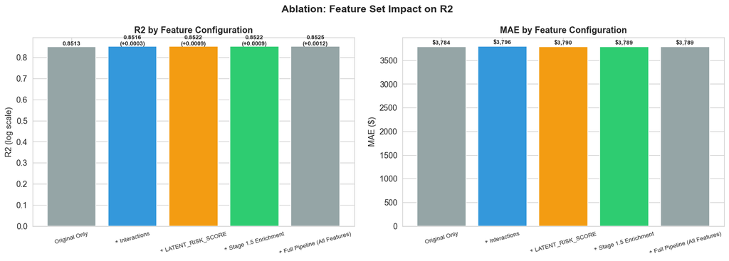

```
Saving...
Saved to ../data/processed_v2/model_ready_stage2.parquet: 60,602 rows, 68 cols
```

## Summary

**2D Classification Pipeline (v3):**

- **Stage 1** (5.1): 10-class 2D classification (Y1 cost level × transition direction)
- **Stage 1.5 kept:** ENGAGEMENT_SCORE (direct), ESCALATION_MAGNITUDE (regression on DELTA_BIN), Raw Rx features (4 vars)
- **Stage 1.5 removed:** PROB_CRISIS_MODE, ESCALATION_SCORE, HAZARD_DISCONTINUE (all redundant)
- **Stage 2:** 2D class-specific XGBoost on log(1+cost) target, with LATENT_RISK_SCORE as a feature within each class
- **Evaluation:** R2 reported on BOTH log and dollar scales